```
                                            Project Title: Loan Default Prediction System
```

# Project Goal:To build a machine learning model that can predict whether a loan applicant is likely to default or repay the loan, using historical data.

> > Step 1: Data Loading and Cleaning

```python
import pandas as pd
import numpy as np
import matplotlib.pyplot as plt
import seaborn as sns
from sklearn.model_selection import train_test_split
from sklearn.preprocessing import LabelEncoder, StandardScaler
from sklean.metrics import accuracy_score, confusion_matrix, classification_report
```

# Explanation:

pandas and numpy are used for data manipulation and numerical operations.

matplotlib.pyplot and seaborn are used for visualizing the data and relationships between variables.

train_test_split helps split the dataset into training and testing sets.

LabelEncoder is used to convert categorical columns into numeric format.

StandardScaler (if used) scales the features.

accuracy_score, confusion_matrix, and classification_report are evaluation metrics for model performance.

> > Step 2: Load the Dataset

```python
import pandas as pd

df = pd.read_csv('loan_data.csv')
df.head
```

```
<bound method NDFrame.head of     Loan_ID  Gender Married Dependents     Education Self_Employed  \
0  LP001002    Male     Yes          0      Graduate            No
1  LP001003    Male     Yes          1      Graduate            No
2  LP001005    Male     Yes          0      Graduate           Yes
3  LP001006    Male      No          0  Not Graduate            No
4  LP001008    Male     Yes          2      Graduate            No
5  LP001011    Male     Yes          2      Graduate           Yes
6  LP001013    Male     Yes          0  Not Graduate            No
7  LP001014    Male     Yes         3+      Graduate            No
8  LP001018  Female     Yes          0      Graduate            No
9  LP001020    Male     Yes          1      Graduate            No

   ApplicantIncome  CoapplicantIncome  LoanAmount  Loan_Amount_Term  \
0             5849                0.0         128             360.0
1             4583             1508.0         128             360.0
```

[output cut: 20 more lines]

# Explanation:

The dataset is loaded using pd.read_csv() from a file named 'loan_data.csv'.

> > Step 3: Drop Unnecessary Columns

```python
df.drop(columns=['Loan_ID'], inplace=True)
```

# Explanation:

The Loan_ID column is removed because it is just a unique identifier and does not help in predicting the loan status.

Removing such irrelevant columns helps improve model performance by eliminating noise.

> > Step 4: Understand the Dataset (EDA - Part 1)

```python
df.info()
df.describe()
```

[output not shown]

|  | ApplicantIncome | CoapplicantIncome | LoanAmount | Loan_Amount_Term | Credit_History |
| --- | --- | --- | --- | --- | --- |
| count | 10.000000 | 10.000000 | 10.00000 | 10.0 | 10.000000 |
| mean | 4964.800000 | 2457.600000 | 162.00000 | 360.0 | 0.900000 |
| std | 3079.278047 | 3270.009147 | 84.50378 | 0.0 | 0.316228 |
| min | 2333.000000 | 0.000000 | 66.00000 | 360.0 | 0.000000 |
| 25% | 3009.000000 | 377.000000 | 122.00000 | 360.0 | 1.000000 |
| 50% | 4294.500000 | 1521.000000 | 134.50000 | 360.0 | 1.000000 |
| 75% | 5741.000000 | 2467.500000 | 165.50000 | 360.0 | 1.000000 |
| max | 12841.000000 | 10968.000000 | 349.00000 | 360.0 | 1.000000 |

# Explanation:

df.info() gives a summary of the dataset including:

Column names

Data types (int64, float64, object)

Non-null counts — this helps detect missing values.

df.describe() provides statistical insights:

Count, mean, standard deviation, min, max, and percentiles for numerical columns.

Helps understand the range and distribution of values (e.g., income, loan amount, etc.).

These commands help identify any data cleaning or transformation needed before modeling

```python
from sklearn.preprocessing import LabelEncoder

le = LabelEncoder()

# Loop through each column and encode if it's of object type
for col in df.columns:
    if df[col].dtype == 'object':
        df[col] = le.fit_transform(df[col])
```

```python
df.dtypes
```

```
Gender                 int32
Married                int32
Dependents             int32
Education              int32
Self_Employed          int32
ApplicantIncome        int64
CoapplicantIncome    float64
LoanAmount             int64
Loan_Amount_Term     float64
Credit_History       float64
Property_Area          int32
Loan_Status            int32
dtype: object
```

# step 5: Split into Training and Testing Sets

In this step, we prepare the dataset for training and evaluation by separating the input features (X) from the target label (y).

Loan_Status is the target column, which contains the labels: whether the loan was approved or not (Y or N).

The rest of the columns are input features that help us predict this outcome.

We use train_test_split() from sklearn.model_selection to split the dataset:

```python
X = df.drop('Loan_Status', axis=1)
y = df['Loan_Status']

from sklearn.model_selection import train_test_split
X_train, X_test, y_train, y_test = train_test_split(
    X, y, test_size=0.2, random_state=42)
```

# Explanation:

X = df.drop('Loan_Status', axis=1): Drops the target column and stores all other columns in X.

y = df['Loan_Status']: Stores the target labels in y.

train_test_split(...): Randomly splits the data into training and testing subsets:

80% of data → training (X_train, y_train)

20% of data → testing (X_test, y_test)

random_state=42: Ensures reproducibility. The same split will occur every time you run the code

> > step 6 Logistic Regression Model – Training and Prediction

```python
from sklearn.linear_model import LogisticRegression

lr_model = LogisticRegression()
lr_model.fit(X_train, y_train)
y_pred_lr = lr_model.predict(X_test)
```

# Explanation:

LogisticRegression() creates a logistic regression classifier from scikit-learn.

fit(X_train, y_train) trains the model using the training features and labels.

predict(X_test) uses the trained model to predict the outcomes (loan status) for the test data.

```python
#  Step 7: Decision Tree Model – Training and Evaluation
```

```python
from sklearn.tree import DecisionTreeClassifier

dt_model = DecisionTreeClassifier()
dt_model.fit(X_train, y_train)
y_pred_dt = dt_model.predict(X_test)

print("✅ Decision Tree Evaluation")
print("Accuracy:", accuracy_score(y_test, y_pred_dt))
print("Confusion Matrix:\n", confusion_matrix(y_test, y_pred_dt))
print("Classification Report:\n", classification_report(y_test, y_pred_dt))
```

```
✅ Decision Tree Evaluation
Accuracy: 0.5
Confusion Matrix:
 [[0 1]
 [0 1]]
Classification Report:
               precision    recall  f1-score   support

           0       0.00      0.00      0.00         1
           1       0.50      1.00      0.67         1

    accuracy                           0.50         2
   macro avg       0.25      0.50      0.33         2
weighted avg       0.25      0.50      0.33         2
```

Explanation:

DecisionTreeClassifier() initializes the model.

fit() trains the model using the training data.

predict() makes predictions on the test set.

accuracy_score() calculates the percentage of correctly predicted results.

confusion_matrix() shows how well the model is classifying each class.

classification_report() gives precision, recall, and F1-score for detailed evaluation.

# Step 8: Random Forest Model – Training and Evaluation

```python
from sklearn.ensemble import RandomForestClassifier

rf_model = RandomForestClassifier()
rf_model.fit(X_train, y_train)
y_pred_rf = rf_model.predict(X_test)

print("✅ Random Forest Evaluation")
print("Accuracy:", accuracy_score(y_test, y_pred_rf))
print("Confusion Matrix:\n", confusion_matrix(y_test, y_pred_rf))
print("Classification Report:\n", classification_report(y_test, y_pred_rf))
```

```
✅ Random Forest Evaluation
Accuracy: 0.5
Confusion Matrix:
 [[0 1]
 [0 1]]
Classification Report:
               precision    recall  f1-score   support

           0       0.00      0.00      0.00         1
           1       0.50      1.00      0.67         1

    accuracy                           0.50         2
   macro avg       0.25      0.50      0.33         2
weighted avg       0.25      0.50      0.33         2
```

# Explanation:

RandomForestClassifier() creates an ensemble of decision trees to improve accuracy and reduce overfitting.

The model is trained using .fit() and makes predictions using .predict().

accuracy_score() gives the overall accuracy on the test data.

confusion_matrix() breaks down the true vs predicted values.

classification_report() provides precision, recall, and F1-score.

# Step 9: Model Comparison – Accuracy

```python
models = {
    "Logistic Regression": accuracy_score(y_test, y_pred_lr),
    "Decision Tree": accuracy_score(y_test, y_pred_dt),
    "Random Forest": accuracy_score(y_test, y_pred_rf)
}

print("Model Comparison (Accuracy):")
for name, acc in models.items():
    print(f"{name}: {acc:.2f}")
```

```
Model Comparison (Accuracy):
Logistic Regression: 0.50
Decision Tree: 0.50
Random Forest: 0.50
```

# Explanation:

We store each model’s accuracy score in a dictionary.

This helps identify which model performs best on the test data.

On small datasets like ours, accuracy can vary significantly — so in real-world scenarios, we'd prefer more data and additional metrics like cross-validation.

> > Step 10: Model Accuracy Visualization

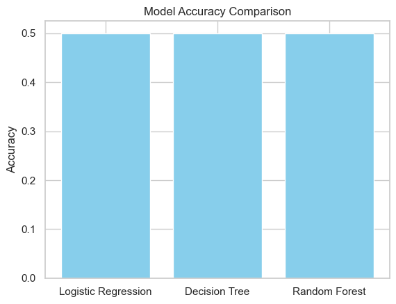

```python
import matplotlib.pyplot as plt

model_names = list(models.keys())
accuracies = list(models.values())

plt.bar(model_names, accuracies, color='skyblue')
plt.title("Model Accuracy Comparison")
plt.ylabel("Accuracy")
plt.show()
```

# Explanation:

The bar chart shows how each model performed in terms of accuracy.

# Conclusion:

All models gave an accuracy of 50%, which indicates poor generalization due to insufficient data.

For better performance:

A larger dataset should be used (at least 100–500+ records).

Feature engineering and hyperparameter tuning can be applied.

Scaling and normalization can improve Logistic Regression.